# 作業一: Sort

# 繳交期限: 2019.10.18

# 姓名 / 學號: 吳政翰 03151107

# 目錄

- 快速排序法 Quick Sort
- 插入排序法 Insertion Sort
- 氣泡排序法 Bubble Sort

每種方法均附含解釋、舉例、流程圖、程式碼、測試。

### Path

```python
import os
os.chdir(r'C:\Users\user\Desktop\資料結構\Sort\圖')
```

### Package

```python
%matplotlib inline
import matplotlib.pyplot as plt
import matplotlib.image as mpimg
```

# 1. 快速排序法 Quick Sort

## 解釋

- 快速排序法 (Quick Sort) 會先在資料中任意找一個值作為中間值，把小於中間值的資料放在左邊而把大於中間值的資料放右邊，再以同樣的方式分別處理左右兩邊的資料，直到完成為止。
- 該方法是目前公認最佳的排序法。
- 最快的情況下，時間複雜度為 O(n$\log_{2}(n)$。
- 最壞況下就是每次挑中的中間值不是最大就是最小，時間複雜度為 O($n^{2})。

## 舉例

將資料「35, 40, 86, 54, 16, 63, 75, 21」使用快速排序法進行由小而大的遞增排序。

### Step1

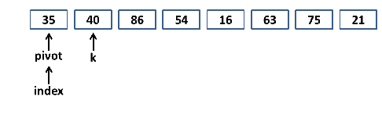

```python
plt.figure(figsize=(8,3))
g = mpimg.imread(r'.\QuickSort\1.png')
plt.axis('off')
plt.imshow(g)
```

#### 將變數pivot設為數列的第一數值，index指標同樣指向數列的第一數值，k指標向右訪尋直到數列最後一個值。

### Step2

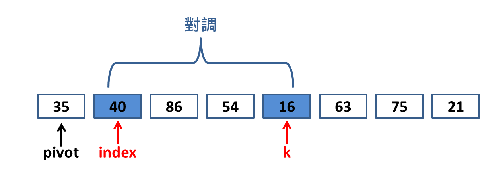

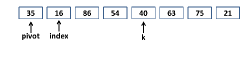

```python
g1 = mpimg.imread(r'.\QuickSort\2.png')
g2 = mpimg.imread(r'.\QuickSort\3.png')
plt.figure(figsize=(8,3))
plt.axis('off')
plt.imshow(g1)
plt.show()
plt.figure(figsize=(8,3))
plt.axis('off')
plt.imshow(g2)
plt.show()
```

#### 當k指標訪尋到某個數值小於pivot時，index指標向右移一格，並且index指標所指到的數值與k指標所指到的數值對調。

### Step3

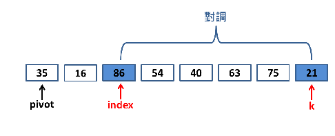

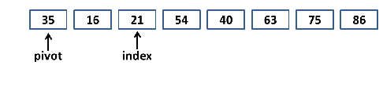

```python
g1 = mpimg.imread(r'.\QuickSort\4.png')
g2 = mpimg.imread(r'.\QuickSort\5.png')
plt.figure(figsize=(8,3))
plt.axis('off')
plt.imshow(g1)
plt.show()
plt.figure(figsize=(8,3))
plt.axis('off')
plt.imshow(g2)
plt.show()
```

#### k指標繼續向右訪尋，直到數列最後一個值為止。當k指標訪尋到某個數值小於pivot時，index指標向右移一格，並且index指標所指到的數值與k指標所指到的數值對調。

### Step4

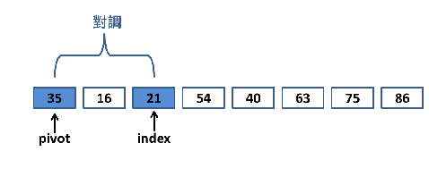

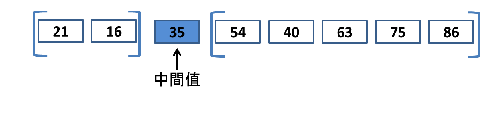

```python
g1 = mpimg.imread(r'.\QuickSort\6.png')
g2 = mpimg.imread(r'.\QuickSort\7.png')
plt.figure(figsize=(8,3))
plt.axis('off')
plt.imshow(g1)
plt.show()
plt.figure(figsize=(8,3))
plt.axis('off')
plt.imshow(g2)
plt.show()
```

#### 當k指標訪尋完畢後，pivot值與index指標所指向的值對調。pivot將變為數列的中間值，將數列分成左右兩個子數列。小於中間值的資料在左邊，大於中間值的資料在右邊。

### Step5

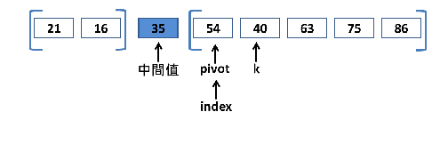

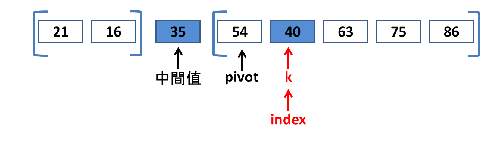

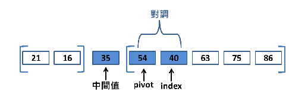

[figure not shown]

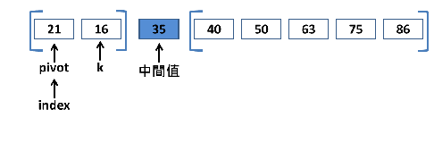

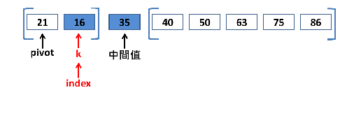

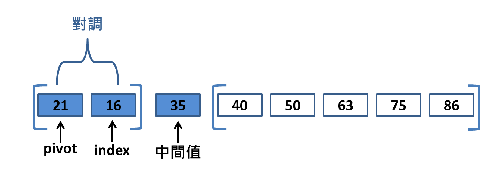

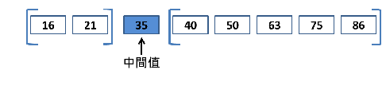

[figure not shown]

```python
g1 = mpimg.imread(r'.\QuickSort\8.png')
g2 = mpimg.imread(r'.\QuickSort\9.png')
g3 = mpimg.imread(r'.\QuickSort\10.png')
g4 = mpimg.imread(r'.\QuickSort\11.png')
g5 = mpimg.imread(r'.\QuickSort\12.png')
g6 = mpimg.imread(r'.\QuickSort\13.png')
g7 = mpimg.imread(r'.\QuickSort\14.png')
g8 = mpimg.imread(r'.\QuickSort\15.png')
g9 = mpimg.imread(r'.\QuickSort\16.png')

list=[g1,g2,g3,g4,g5,
      g6,g7,g8,g9]
for i in list:
    plt.figure(figsize=(8,3))
    plt.axis('off')
    plt.imshow(i)
    plt.show()
```

#### 接著分別在左右兩個子集合內做step1~step4的動作，直到完成排序為止。

## 程式流程圖

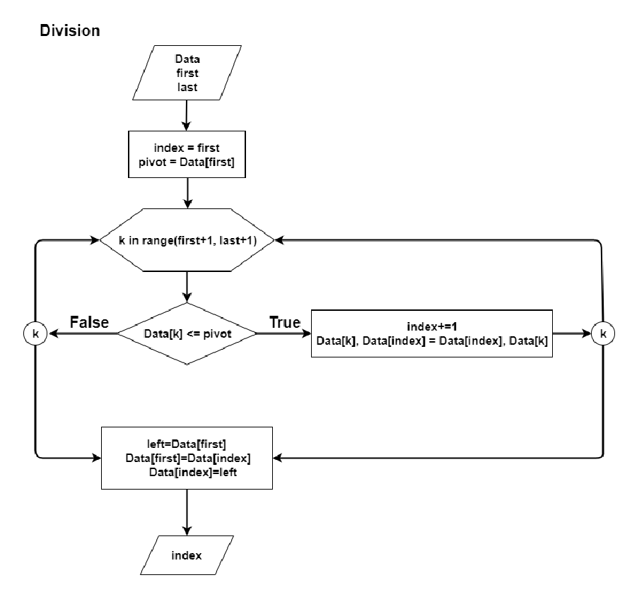

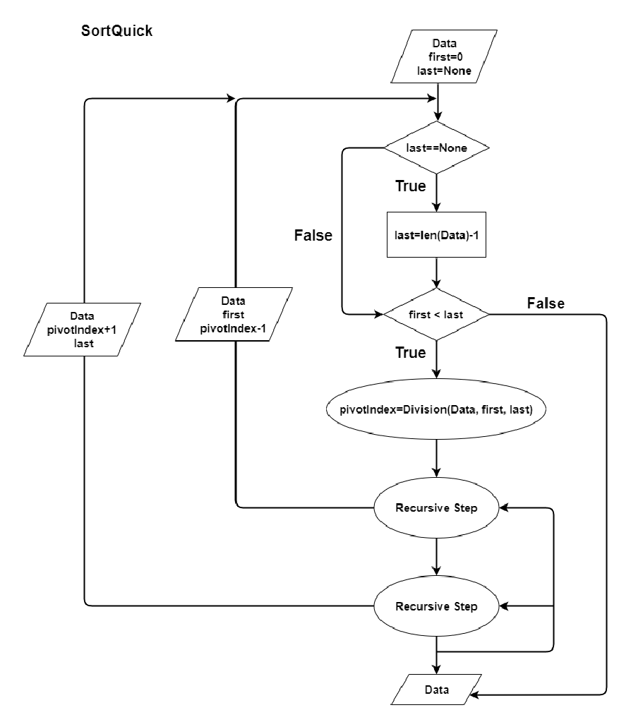

```python
plt.figure(figsize=(15,20))
flowchart = mpimg.imread(r'.\QuickSort\QuickSort_flowchart1.png')
plt.axis('off')
plt.imshow(flowchart)

plt.figure(figsize=(15,20))
flowchart = mpimg.imread(r'.\QuickSort\QuickSort_flowchart2.png')
plt.axis('off')
plt.imshow(flowchart)
```

## 程式碼

```python
def sortQuick(Data, first=0, last=None):
    if last==None:
        last=len(Data)-1
    if first < last:
        pivotIndex=Division(Data, first, last)
        sortQuick(Data, first, pivotIndex-1)
        sortQuick(Data, pivotIndex+1, last)
    return Data

def Division(Data, first, last):
    index=first
    pivot=Data[first]
    for k in range(first+1, last+1):
        if Data[k] <= pivot:
            index+=1
            Data[k], Data[index] = Data[index], Data[k]
    left=Data[first]
    Data[first]=Data[index]
    Data[index]=left
    return index
```

- 定義函式sortQuick()來執行排序。
- 以遞迴呼叫本身的函式，分別處理左邊和右邊的元素。
- 定義函示Division()來執行快速排序法的分割動作。指定數列第一個數值作為pivot，指標index最初也指向pivot。依據指標k指向的值和pivot做比較來決定是否要換位置，當k指向的值小於pivot，指標index向後移動一位，k所指向的值與index所指向的值對調，指標k再繼續向後訪尋；當指標k移動到數列最後一個數值並且所指向過的數值也都與pivot比較過後，pivot將與指標index所指向的數值對調。此時pivot將會成為該數列的中間值，該中間值將數列分成左右兩個子數列，位於中間值左邊的數列均小於中間值；位於中間值右邊的數列均大於中間值。同時函示Division()還會回傳中間值在數列的位置。
- 左右兩個子數列再透過遞迴呼叫本身的函式各自進行排序。

## 測試

```python
data1=[4,3,2,1]
data2=[1,2,3,4]
data3=[1,2,4,3]
data4=[4,2,3,1]
```

```python
print('原始資料: ',data1)
print('排序後資料: ',sortQuick(data1),'\n')
print('原始資料: ',data2)
print('排序後資料: ',sortQuick(data2),'\n')
print('原始資料: ',data3)
print('排序後資料: ',sortQuick(data3),'\n')
print('原始資料: ',data4)
print('排序後資料: ',sortQuick(data4))
```

```
原始資料:  [4, 3, 2, 1]
排序後資料:  [1, 2, 3, 4]

原始資料:  [1, 2, 3, 4]
排序後資料:  [1, 2, 3, 4]

原始資料:  [1, 2, 4, 3]
排序後資料:  [1, 2, 3, 4]

原始資料:  [4, 2, 3, 1]
排序後資料:  [1, 2, 3, 4]
```

# 2. 插入排序法 Insertion Sort

## 解釋

- 插入排序法 (Insertion Sort) 的原理是將一個元素插入一串已排序的元素之中，使該串排序仍然按照順序排序。將第i個鍵值插入到前面所有鍵值當中，第一個大於本身鍵值之前，若沒有則置於最後面。
- 最壞情況時間複雜度為 $O(n^{2})$，共運行 (n-1) + (n-2) + (n-3) +...+ 3 + 2 + 1 = $\frac{n(n-1)}{2}$ 次掃描。
- 最佳情況時間複雜度為 $O(n)$。

## 舉例

將資料「78, 56, 43, 12, 63, 23」使用插入排序法進行由小而大的遞增排序。

## 程式流程圖

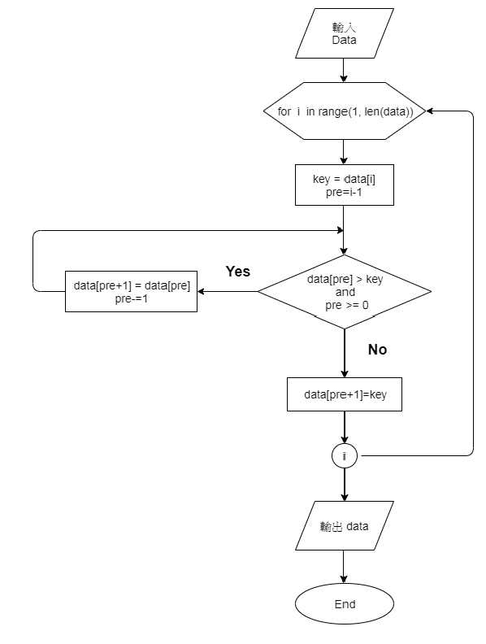

```python
plt.figure(figsize=(10,15))
flowchart = mpimg.imread(r'.\InsertionSort\InsertionSort_flowchart.png')
plt.axis('off')
plt.imshow(flowchart)
```

## 程式碼

```python
def sortInsertion(data):
    for i in range(1,len(data)):
        key = data[i]
        pre = i-1

        while data[pre] > key and pre >= 0:
            data[pre+1] = data[pre]
            pre-=1

        data[pre+1]=key

    return data
```

1. 定義函式 sortInsertion ，以 List 物件為參數來進行「插入排序法」。
2. 以 for 迴圈讀取物件，從第2項讀取，再以變數key作為每次迴圈中欲插入在前面已排序過的元素的鍵值；變數pre則作為儲存前一項的索引。
3. while迴圈處理陣列中前、後項比大小的問題，當前項值大於後項值時，改變索引並將項目向前推移。

## 測試

```python
data1=[4,3,2,1]
data2=[1,2,3,4]
data3=[1,2,4,3]
data4=[4,2,3,1]
```

```python
print('原始資料: ',data1)
print('排序後資料: ',sortInsertion(data1),'\n')
print('原始資料: ',data2)
print('排序後資料: ',sortInsertion(data2),'\n')
print('原始資料: ',data3)
print('排序後資料: ',sortInsertion(data3),'\n')
print('原始資料: ',data4)
print('排序後資料: ',sortInsertion(data4))
```

```
原始資料:  [4, 3, 2, 1]
排序後資料:  [1, 2, 3, 4]

原始資料:  [1, 2, 3, 4]
排序後資料:  [1, 2, 3, 4]

原始資料:  [1, 2, 4, 3]
排序後資料:  [1, 2, 3, 4]

原始資料:  [4, 2, 3, 1]
排序後資料:  [1, 2, 3, 4]
```

# 3. 氣泡排序法 Bubble Sort

## 解釋

- 氣泡排序是把陣列中相鄰元素之鍵值做比較，若相鄰元素大小順序有誤，則對調後再進行下一個相鄰的元素比較，直到將最大的元素排序到陣列的尾端。接著重複原來動作直到將次大的元素排到陣列尾端。以此類推，直到陣列完成排序為止。
- 最壞情況時間複雜度為 $O(n^{2})$，共運行 (n-1) + (n-2) + (n-3) +...+ 3 + 2 + 1 = $\frac{n(n-1)}{2}$ 次掃描。
- 最好的情況只須完成一次掃描，發現沒有做交換的動作則表示已完成排序。所以只做了n-1次比較。時間複雜度為 $O(n)$。

## 舉例

以下利用數列「25, 33, 11, 78, 65, 57」  
將範圍內最大的元素排到定位的過程稱為「回合」。

#### 第一回合

1. 一開始資料都放在同一陣列中，比較相鄰的陣列元素大小，依照順序來決定是否要做交換。
2. 從輸入陣列的第一個元素開始「25」，它小於33不互換，33比11大，得互換。所以較大的元素會逐漸地往下方移動，所以找到最大值「78」，結束第一回合的結果。
3. 第一回合的範圍中有6個項目，範圍從數列[0]~數列[5]，比較了5次，進行了3次交換。

[figure not shown]

```python
plt.figure(figsize=(10,7))
g = mpimg.imread(r'.\BubbleSort\BubbleSort1.png')
plt.axis('off')
plt.imshow(g)
```

#### 第二回合

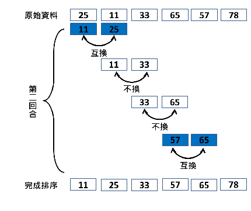

```python
plt.figure(figsize=(9,6))
g = mpimg.imread(r'.\BubbleSort\BubbleSort2.png')
plt.axis('off')
plt.imshow(g)
```

## 程式流程圖

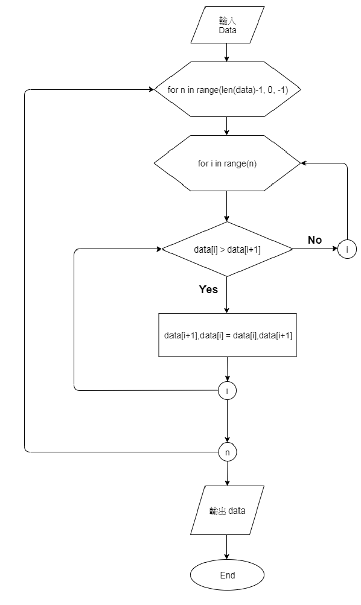

```python
plt.figure(figsize=(10,20))
flowchart = mpimg.imread(r'.\BubbleSort\BubbleSort_flowchart.png')
plt.axis('off')
plt.imshow(flowchart)
```

## 程式碼

```python
def sortBubble(data):
    for n in range(len(data)-1,0,-1):
        for i in range(n):
            if data[i]>data[i+1]:
                data[i+1],data[i]=data[i],data[i+1]
    return data
```

1. 定義函式sortBubble
2. 外層迴圈紀錄每一回合排序的範圍
3. 將元素兩兩比較，並以if配合條件判斷，若前一個項目比後一個項目的值大就互換位置。

## 測試

```python
data1=[4,3,2,1]
data2=[1,2,3,4]
data3=[1,2,4,3]
data4=[4,2,3,1]
```

```python
print('原始資料: ',data1)
print('排序後資料: ',sortBubble(data1),'\n')
print('原始資料: ',data2)
print('排序後資料: ',sortBubble(data2),'\n')
print('原始資料: ',data3)
print('排序後資料: ',sortBubble(data3),'\n')
print('原始資料: ',data4)
print('排序後資料: ',sortBubble(data4))
```

```
原始資料:  [4, 3, 2, 1]
排序後資料:  [1, 2, 3, 4]

原始資料:  [1, 2, 3, 4]
排序後資料:  [1, 2, 3, 4]

原始資料:  [1, 2, 4, 3]
排序後資料:  [1, 2, 3, 4]

原始資料:  [4, 2, 3, 1]
排序後資料:  [1, 2, 3, 4]
```